# ch01_03_pytorch_LinearRegression_wc_V10

### 선형회귀 문제를 pytorch를 활용하여 풀어보기

### 학습 목표

- pytorch로 구현하는 딥러닝 기본에 대해 알아본다.
- pytorch를 이용하여 기본 선형회귀 모델을 만들어본다.

### 목차

01. 데이터 확인  
02. 경사 계산 및 파라미터 수정  
03. 실전 모델 만들어보기 - 선형회귀 구현하기  
04. 최종 학습 결과 확인

### 01 데이터 확인

목차로 이동하기

### 데이터

- 다섯명의 사람
- 신장과 체중은 다음과 같다.
  - (166, 58.7), (176, 75.7), (171, 62.1), (173, 70.4), (169, 60.1)
- 주어진 신장으로부터 체중을 예측하는 머신러닝 모델을 만들어보기

```python
import matplotlib.pyplot as plt
import seaborn as sns
import numpy as np
import torch
```

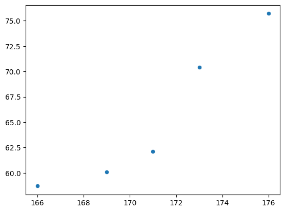

```python
height = [166,176, 171, 173, 169]
weight = [58.7, 75.7, 62.1, 70.4, 60.1]

sns.scatterplot(x=height, y=weight)
```

### 선형 회귀 구하기

- 산포도는 신장과 체중사이에서 일정한 관계가 있다.
- 다음과 같이 표현된 것은 1차 함수로 근사할 수 있을 것이다.
- 다섯개의 점과 가장 가까운 1차 함수를 구하는 것을 우리는 선형회귀라 말할 수 있다.

### 경사하강법

- 딥러닝 프로그래밍은 수학적으로 '경사하강법'으로 불리는 알고리즘에 기반하게 된다.
- 편미분, 선형대수와 같은 수학적 지식이 필요.
- 꼭대기에서 제일 낮은 지점까지 이동하는 방법.
- 경사하강법은 가장 작은 손실(오차)값을 구하는 문제 '최솟값을 구하는 문제'로 변경
- 예측 함수를 이용하여 출력 값을 구하면 원래 정답과 비교하여 손실(loss)을 계산한다. 이를 토대로 경사를 계산하여 경사값 변경하고, 파라미터(W)와 B(바이어스)를 조금씩 수정해 간다.
  - 경사값에 작은 정수(학습률) lr를 곱해, 그 값만큼 W, B를 줄여나간다.
- 손실함수(loss)는 예측 함수에 따라 적절한 것을 고른다.
  - 회귀 모델의 경우, 평균제곱오차(MSE)를 선택했다.

```python
dat1 = np.array(height)
dat2 = np.array(weight)
dat1, dat2
```

```
(array([166, 176, 171, 173, 169]), array([58.7, 75.7, 62.1, 70.4, 60.1]))
```

```python
# 여러 개의 2차원 데이터 배열(예: 이미지 채널)을 하나의 3차원 배열로 결합할 때 사용
# NumPy의 dstack 함수를 사용하여 두 배열(dat1과 dat2)을 세 번째 축(깊이)을 따라 쌓습니다.
dat_all = np.dstack([dat1, dat2])
dat_all
```

```
array([[[166. ,  58.7],
        [176. ,  75.7],
        [171. ,  62.1],
        [173. ,  70.4],
        [169. ,  60.1]]])
```

```python
### 데이터를 평균값을 0으로 되도로 변환해 준다.
X = dat1 - dat1.mean()
Y = dat2 - dat2.mean()
```

### X와 Y를 텐서 변수로 변환하기

```python
X = torch.tensor(X).float()
Y = torch.tensor(Y).float()

# 결과확인
print(X)
print(Y)
```

```
tensor([-5.,  5.,  0.,  2., -2.])
tensor([-6.7000, 10.3000, -3.3000,  5.0000, -5.3000])
```

## 예측 함수 : Yp = W * X + B

- W와 B의 정의
- W와 B는 경사 계산을 위해 requires_grad=True로 설정.
  - requires_grad = True를 통해 미분 대상의 텐서가 됨.

```python
W = torch.tensor(1.0, requires_grad = True).float()
B = torch.tensor(1.0, requires_grad = True).float()
```

- 두 변수의 초깃값을 1.0으로 설정.

### 예측값 Yp의 계산

```python
def pred(X):
    return W * X + B
```

```python
# 예측 값 계산
Yp = pred(X)

# 결과 확인
print(Yp)
```

```
tensor([-4.,  6.,  1.,  3., -1.], grad_fn=<AddBackward0>)
```

### 손실함수 계산

```python
def mse(Yp, Y):
    loss = ( (Yp - Y) ** 2 ).mean()
    return loss
```

### 손실 계산

```python
loss = mse(Yp, Y)

print(loss)
```

```
tensor(13.3520, grad_fn=<MeanBackward0>)
```

### 02 경사 계산 및 파라미터 수정

목차로 이동하기

```python
# W = torch.tensor(1.0, requires_grad = True).float()
# B = torch.tensor(1.0, requires_grad = True).float()
```

```python
# 경사값 확인
# W는 일반적으로 가중치(Weight) 텐서를, B는 편향(Bias) 텐서를 나타냅니다.
# .grad 속성은 이 텐서들에 대한 손실 함수의 기울기(gradient)를 저장합니다.
# 경사는 손실 함수를 해당 파라미터(W 또는 B)로 편미분한 값입니다.
# 이 값은 해당 파라미터가 손실 함수에 미치는 영향의 방향과 크기를 나타냅니다.
print(W.grad)
print(B.grad)
```

```
None
None
```

```python
# 경사 계산은 backward()로 호출로 가능
# 보통 loss.backward() 메서드를 호출한 후에 이 경사 값들이 계산됩니다.
loss.backward()
```

```python
# 경사값 확인
print(W.grad)
print(B.grad)
```

```
tensor(-19.0400)
tensor(2.0000)
```

### 파라미터 수정

- 경사 계산 후, 그 값에 일정한 학습률 lr(0.01이나 0.001과 같은 값으로 설정)을 곱하여, 원래의 파라미터에서 빼준다.

```python
# 학습률 정의
lr = 0.001

# 경사를 기반으로 파라미터 수정
W = W - lr * W.grad
B = B - lr * B.grad
```

```python
print(W)
print(B)
```

```
tensor(1.0190, grad_fn=<SubBackward0>)
tensor(0.9980, grad_fn=<SubBackward0>)
```

- 초깃값이 W, B가 모두 1이었다. W는 증가하는 방향으로, B는 감소하는 방향으로 조금씩 변화했다.
- 이 계산을 반복해서 W와 B를 최적의 값으로 수렴시키는 것이 경사 하강법이다.

### 03. 실전 모델 만들어보기 - 선형회귀 구현하기

목차로 이동하기

- 가중치(Weight)와 편향(bias) 초기화
- 경사 하강법 구현
  - SGD는 경사 하강법의 일정, lr은 학습률(learning rate)를 의미)
- SGD - 확률적 경사 하강법(Stochastic Gradient Descent)
  - 점진적 학습의 대표적 알고리즘
  - 학습용 데이터 세트에서 샘플 하나씩 꺼내(랜덤) 손실 함수의 경사를 따라 최적의 모델을 찾는 알고리즘

### 투자한 시간과 게임 캐릭터 능력치 향상. 상관관계 예측

- 4시간 투자한다면 게임 캐릭터 능력 향상은 어떻게 될까?

```python
# 도구 임포트
import torch
import torch.nn as nn
import torch.nn.functional as F
import torch.optim as optim
```

```python
# 초기화
W = torch.zeros(1, requires_grad=True)
b = torch.zeros(1, requires_grad=True)
```

```python
# optimizer 설정
optimizer = optim.SGD([W, b], lr=0.01)

# 경사 하강법 반복
num_epochs = 200

# 학습 기록을 위한 배열 초기화
hist = np.zeros( (0, 2))
```

| 시간(hours) | 시간당능력치향상(p) |
| --- | --- |
| 1 | 200 |
| 2 | 400 |
| 3 | 600 |

```python
# 데이터
X = torch.FloatTensor([[1], [2], [3]])
Y = torch.FloatTensor([[200], [400], [600]])
```

```python
X, Y
```

```
(tensor([[1.],
         [2.],
         [3.]]),
 tensor([[200.],
         [400.],
         [600.]]))
```

```python
def mse(Yp, Y):
    loss = ( (Yp - Y) ** 2 ).mean()
    return loss
```

```python
# 루프 처리
for epoch in range(num_epochs + 1):

    # 예측 계산
    Yp = W * X + B

    # 손실 계산
    loss = mse(Yp, Y)

    # Gradient 초기화
    optimizer.zero_grad()
    # 경사 계산 - 역전파를 통한 기울기 계산
    loss.backward()
    # 파라미터 업데이트
    optimizer.step()

    # 손실 기록
    if (epoch % 10 == 0):
        item = np.array([epoch, loss.item()])
        hist = np.vstack( ( hist, item ))
        print(f"epoch = {epoch}  loss = {loss:.4f}")
```

```
epoch = 0  loss = 185869.2656
epoch = 10  loss = 26191.6309
epoch = 20  loss = 3690.8821
epoch = 30  loss = 520.2183
epoch = 40  loss = 73.4279
epoch = 50  loss = 10.4696
epoch = 60  loss = 1.5975
epoch = 70  loss = 0.3473
epoch = 80  loss = 0.1712
epoch = 90  loss = 0.1464
epoch = 100  loss = 0.1429
epoch = 110  loss = 0.1424
epoch = 120  loss = 0.1423
epoch = 130  loss = 0.1423
epoch = 140  loss = 0.1423
epoch = 150  loss = 0.1423
epoch = 160  loss = 0.1423
epoch = 170  loss = 0.1423
epoch = 180  loss = 0.1423
epoch = 190  loss = 0.1423
epoch = 200  loss = 0.1423
```

### 04. 최종 학습 결과 확인

목차로 이동하기

```python
hist
```

```
array([[0.00000000e+00, 1.85869266e+05],
       [1.00000000e+01, 2.61916309e+04],
       [2.00000000e+01, 3.69088208e+03],
       [3.00000000e+01, 5.20218323e+02],
       [4.00000000e+01, 7.34279480e+01],
       [5.00000000e+01, 1.04695635e+01],
       [6.00000000e+01, 1.59749067e+00],
       [7.00000000e+01, 3.47343534e-01],
       [8.00000000e+01, 1.71174988e-01],
       [9.00000000e+01, 1.46359429e-01],
       [1.00000000e+02, 1.42860174e-01],
       [1.10000000e+02, 1.42365798e-01],
       [1.20000000e+02, 1.42302439e-01],
       [1.30000000e+02, 1.42292589e-01],
       [1.40000000e+02, 1.42291188e-01],
       [1.50000000e+02, 1.42285168e-01],
       [1.60000000e+02, 1.42285168e-01],
       [1.70000000e+02, 1.42285168e-01],
       [1.80000000e+02, 1.42285168e-01],
       [1.90000000e+02, 1.42285168e-01],
       [2.00000000e+02, 1.42285168e-01]])
```

```python
# 최종 파리미터 확인
print("W = ", W.data.numpy())
print("B = ", B.data.numpy())

# 손실 확인
print(f"초기 상태 : 손실 : {hist[0,1]:.4f}")
print(f"최종 상태 : 손실 : {hist[-1,1]:.4f}")
```

```
W =  [199.57222]
B =  0.998
초기 상태 : 손실 : 185869.2656
최종 상태 : 손실 : 0.1423
```

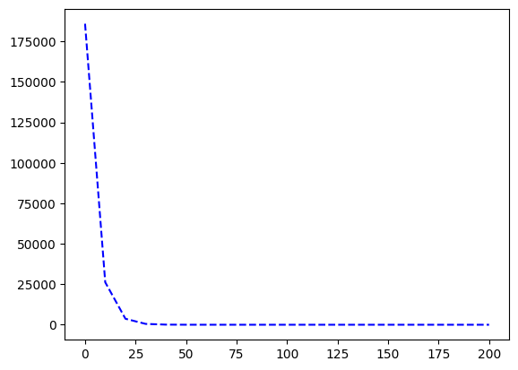

```python
plt.plot(hist[ :, 0], hist[:, 1], '--b')
```

### 실습해 보기 1

- optim.SGD에서 momentum=0.9로 변경후, 확인해 보자.(hist는 hist2로 변경)
- 그래프를 그려보자.